# Statistical Modelling and Inference - Seminar 1

David Rossell and Paul Rognon

```r
knitr::opts_chunk$set(message= FALSE, warning = FALSE)
```

We analyze dataset `cps2012` (R package [hdm](https://cran.r-project.org/web/packages/hdm/index.html)) from a 2012 USA census on wages. FyI the package provides methods to analyze high-dimensional data, in particular to estimate treatment effects in the presence of many confounders, see the [tutorial](https://cran.r-project.org/web/packages/hdm/vignettes/hdm.pdf).

The data contains log-hourly wages, gender, marital status, education, geographic information and several measures of job experience. Type `help("cps2012")` for details. We want to study imbalances between female and male workers, adjusting for other variables such as experience.

```r
PATH= 'C:/Users/paulr/Documents/PhD/teaching/StatInference/seminar1'
library(hdm)
library(glmnet)
library(ggplot2)
library(tidyverse)
library(HDCI)
library(gridExtra)
source(file.path(PATH,"routines_seminar1.R"))
```

# 1 Data formatting, exploratory analysis

We load a data.frame `salary` that contains a pre-processed version of the data where categorical predictors are stored as factors. We check the dimensions of the dataset and first rows.

```r
load(file.path(PATH, 'data/salary.RData'))
xdf= salary
dim(xdf)
```

```
## [1] 29217     6
```

```r
head(xdf)
```

```
##                lnw female marital edu region        exp1
## 1663459 -1.3397597      1 married  sc     ne  0.36991511
## 1663462 -2.1606608      1 married hsd     ne  1.28242379
## 1663463 -0.3876540      0 married hsg     ne  0.02772436
## 1663465 -1.5034837      1 married hsg     ne -0.54259357
## 1663468  0.8346794      0 married  cg     ne -0.42852998
## 1663469 -1.1989278      0 married hsg     ne  0.48397870
```

We then create a numeric design matrix `x` where categories are indicated by dummy variables and that contains pairwise interactions between all predictors. This gives a total of 77 columns in the design matrix.

```r
y= salary$lnw
x= model.matrix(~ female + marital + edu + region + exp1 +
 female:marital + female:edu + female:region + female:exp1
 + marital:edu + marital:region + marital:exp1 + edu:region + edu:exp1 + region:exp1, data=salary)
dim(x)
```

```
## [1] 29217    77
```

```r
head(x[,1:20]) #show first rows for 20 first columns
```

```
##         (Intercept) female maritalmarried maritalnevermarried maritalseparated
## 1663459           1      1              1                   0                0
## 1663462           1      1              1                   0                0
## 1663463           1      0              1                   0                0
## 1663465           1      1              1                   0                0
## 1663468           1      0              1                   0                0
## 1663469           1      0              1                   0                0
##         maritalwidowed educg eduhsd eduhsg edusc regionne regionso regionwe
## 1663459              0     0      0      0     1        1        0        0
## 1663462              0     0      1      0     0        1        0        0
## 1663463              0     0      0      1     0        1        0        0
## 1663465              0     0      0      1     0        1        0        0
## 1663468              0     1      0      0     0        1        0        0
## 1663469              0     0      0      1     0        1        0        0
##                exp1 female:maritalmarried female:maritalnevermarried
```

[output cut: 20 more lines]

We produce a scatterplot for `y` vs `exp1`, indicating females and males in different colors. We then fit a regression model via least squares (function `geom_smooth(method='lm')`), separately for females and males, and add both regression lines to the plot.

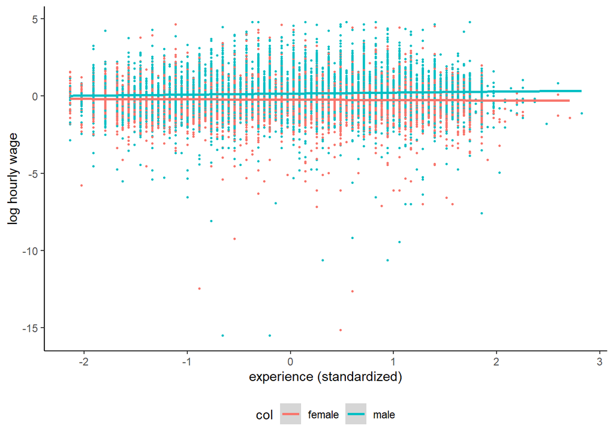

```r
col <- ifelse(x[,"female"]==1,'female','male')
ggplot(xdf,aes(x=exp1,y=lnw,col=col)) + geom_point(size=0.5) + geom_smooth(method='lm') + xlab('experience (standardized)') + ylab('log hourly wage')+ theme_classic() + theme(legend.position = 'bottom')
```

```r
expgroups= cut(xdf$exp1,breaks=seq(-2.5,3.5,by=0.5))
edugroup= as.character(xdf$edu); edugroup[edugroup=='hsg' | edugroup=='hsd']= 'hsd or hsg'
m= tapply(exp(xdf$lnw), list(expgroups,xdf$female,edugroup), 'mean')
```

We create a plot with 2 rows and 2 columns. Note the use of `points` to add points to an existing plot, and `legend` to add a legend.

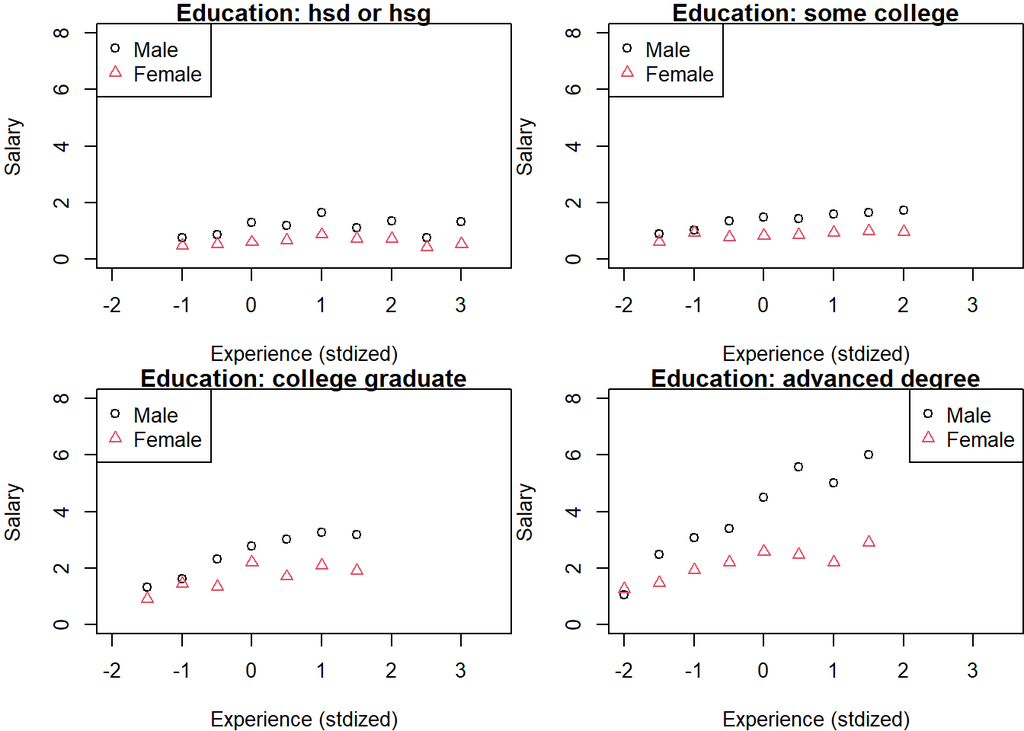

```r
ylim= c(0,8)
elevels= seq(-2,3.5,by=0.5)

par(mfrow=c(2,2), mar=c(4,4,1,0))
plot(elevels,m[,1,'hsd or hsg'],ylab='Salary',xlab='Experience (stdized)',ylim=ylim,main='Education: hsd or hsg')
points(elevels,m[,2,'hsd or hsg'],col=2,pch=2)
legend('topleft',c('Male','Female'),col=c(1,2),pch=c(1,2))

plot(elevels,m[,1,'sc'],ylab='Salary',xlab='Experience (stdized)',ylim=ylim,main='Education: some college')
points(elevels,m[,2,'sc'],col=2,pch=2)
legend('topleft',c('Male','Female'),col=c(1,2),pch=c(1,2))

plot(elevels,m[,1,'cg'],ylab='Salary',xlab='Experience (stdized)',ylim=ylim,main='Education: college graduate')
points(elevels,m[,2,'cg'],col=2,pch=2)
legend('topleft',c('Male','Female'),col=c(1,2),pch=c(1,2))

plot(elevels,m[,1,'ad'],ylab='Salary',xlab='Experience (stdized)',ylim=ylim,main='Education: advanced degree')
points(elevels,m[,2,'ad'],col=2,pch=2)
legend('topright',c('Male','Female'),col=c(1,2),pch=c(1,2))
```

# 2 MLE and cross-validation

We fit the full model regressing `y` on `x` via least squares.

```r
fit.mle= lm(y ~ x[,-1]) #1st column in x is the intercept, already added by lm
b.mle= coef(fit.mle)
summary(fit.mle)
```

```
##
## Call:
## lm(formula = y ~ x[, -1])
##
## Residuals:
##      Min       1Q   Median       3Q      Max
## -16.0742  -0.4557   0.0144   0.4904   5.1527
##
## Coefficients:
##                                      Estimate Std. Error t value Pr(>|t|)
## (Intercept)                          0.676300   0.067204  10.063  < 2e-16 ***
## x[, -1]female                       -0.297154   0.044187  -6.725 1.79e-11 ***
## x[, -1]maritalmarried                0.196526   0.062974   3.121 0.001806 **
## x[, -1]maritalnevermarried          -0.217618   0.077212  -2.818 0.004829 **
## x[, -1]maritalseparated             -0.212297   0.172323  -1.232 0.217969
## x[, -1]maritalwidowed               -0.265695   0.241039  -1.102 0.270343
## x[, -1]educg                        -0.382497   0.069264  -5.522 3.37e-08 ***
## x[, -1]eduhsd                       -1.538018   0.122695 -12.535  < 2e-16 ***
## x[, -1]eduhsg                       -1.075273   0.068359 -15.730  < 2e-16 ***
## x[, -1]edusc                        -0.891408   0.066225 -13.460  < 2e-16 ***
## x[, -1]regionne                      0.112441   0.059925   1.876 0.060618 .
## x[, -1]regionso                      0.056372   0.055735   1.011 0.311817
## x[, -1]regionwe                      0.090034   0.060955   1.477 0.139673
## x[, -1]exp1                          0.199174   0.026117   7.626 2.49e-14 ***
## x[, -1]female:maritalmarried        -0.213269   0.033638  -6.340 2.33e-10 ***
## x[, -1]female:maritalnevermarried    0.060644   0.042075   1.441 0.149497
## x[, -1]female:maritalseparated      -0.135775   0.087064  -1.559 0.118893
## x[, -1]female:maritalwidowed         0.018695   0.140230   0.133 0.893945
## x[, -1]female:educg                  0.042247   0.032770   1.289 0.197347
## x[, -1]female:eduhsd                -0.180414   0.077652  -2.323 0.020166 *
## x[, -1]female:eduhsg                -0.000787   0.035248  -0.022 0.982187
## x[, -1]female:edusc                  0.032416   0.033274   0.974 0.329952
## x[, -1]female:regionne               0.003660   0.029273   0.125 0.900496
## x[, -1]female:regionso              -0.006769   0.027467  -0.246 0.805337
## x[, -1]female:regionwe              -0.004568   0.030400  -0.150 0.880571
## x[, -1]female:exp1                  -0.049064   0.011472  -4.277 1.90e-05 ***
## x[, -1]maritalmarried:educg          0.003106   0.062979   0.049 0.960662
## x[, -1]maritalnevermarried:educg     0.057105   0.075353   0.758 0.448557
## x[, -1]maritalseparated:educg        0.143752   0.171884   0.836 0.402976
## x[, -1]maritalwidowed:educg         -0.238640   0.242006  -0.986 0.324097
```

[output cut: 38 more lines]

```
## x[, -1]eduhsg:regionwe               0.032780   0.051297   0.639 0.522814
## x[, -1]edusc:regionwe                0.046881   0.047283   0.991 0.321454
## x[, -1]educg:exp1                    0.016530   0.018287   0.904 0.366048
## x[, -1]eduhsd:exp1                  -0.068262   0.036135  -1.889 0.058891 .
## x[, -1]eduhsg:exp1                  -0.090764   0.018771  -4.835 1.34e-06 ***
## x[, -1]edusc:exp1                   -0.075603   0.018230  -4.147 3.38e-05 ***
## x[, -1]regionne:exp1                 0.021511   0.016074   1.338 0.180840
## x[, -1]regionso:exp1                 0.012032   0.014707   0.818 0.413291
## x[, -1]regionwe:exp1                 0.023384   0.016134   1.449 0.147241
## ---
## Signif. codes:  0 '***' 0.001 '**' 0.01 '*' 0.05 '.' 0.1 ' ' 1
##
## Residual standard error: 0.8702 on 29140 degrees of freedom
## Multiple R-squared:  0.2447, Adjusted R-squared:  0.2428
## F-statistic: 124.2 on 76 and 29140 DF,  p-value: < 2.2e-16
```

## 2.1 Predictive accuracy

The multiple R-squared (unadjusted) reported above is the squared correlation between `y` and OLS predictions $\hat{y}$: it is an *in-sample* measure.

```r
cor(fit.mle$fitted.values,y)^2
```

```
## [1] 0.2447305
```

To assess the OLS predictive accuracy we use 10-fold cross-validation implemented in function `kfoldCV.mle` in `routines_seminar1.R` copied below.

Remarks: The first column in `x` has all entries equal to 1 (the intercept), `kfoldCV.mle` expects a matrix with no intercept (i.e. `x[,-1]`). `seed=1` sets the random number generator seed (so we all use the same random splits).

```markdown
kfoldCV.mle <- function(y,x,K=10,seed) {
## Perform K-fold cross-validation for least-squares regression estimate
## Input
## - y: response
## - x: data.frame with predictors, intercept should not be present
## - K: number of folds in K-fold cross-validation
## - seed: random number generator seed (optional)
## Output
## - pred: cross-validated predictions for y
## - ssr: residual sum of squares, sum((y-pred)^2)
  if (!missing(seed)) set.seed(seed)
  subset <- rep(1:K,ceiling(nrow(x)/K))[1:nrow(x)]
  subset <- sample(subset,size=nrow(x),replace=FALSE)
  pred <- double(nrow(x))
  if (ncol(x)>0) {
    for (k in 1:K) {
      sel <- subset==k
      fit <- lm(y[!sel] ~ ., data=x[!sel,,drop=FALSE])
      pred[sel] <- predict(fit, newdata=x[sel,,drop=FALSE])
    }
  } else {
    for (k in 1:K) {
      sel <- subset==k
      pred[sel] <- mean(y[!sel],na.rm=TRUE)
    }
  }
  return(list(pred=pred,ssr=sum((pred-y)^2,na.rm=TRUE)))
}
```

We use `kfoldCV.mle` to obtain a 10-fold cross-validated $R^2$ (squared correlation between `y` and cross-validated predictions).

```r
cv.mle= kfoldCV.mle(y=y,x=data.frame(x[,-1]),K=10,seed=1)
r2.mle= cor(cv.mle$pred, y)^2
r2.mle
```

```
## [1] 0.2406662
```

# 3 LASSO

## 3.1 Setting penalization parameter $\lambda$

### 3.1.1 Via cross-validation

We use function `cv.glmnet` to estimate $\lambda$ via 10-fold cross-validation. `glmnet` automatically includes the intercept, hence we use `x[,-1]` to exclude the first column from `x` (that containing the intercept).

```r
fit.lasso= cv.glmnet(x=x[,-1], y=y, nfolds=10)
fit.lasso
```

```
##
## Call:  cv.glmnet(x = x[, -1], y = y, nfolds = 10)
##
## Measure: Mean-Squared Error
##
##       Lambda Index Measure      SE Nonzero
## min 0.001399    56  0.7590 0.02509      62
## 1se 0.027470    24  0.7804 0.02470      16
```

We plot the estimated mean squared prediction error $\widehat{MSPE}$. Since $\widehat{MSPE}$ is a data-based estimate, also plots their standard errors.

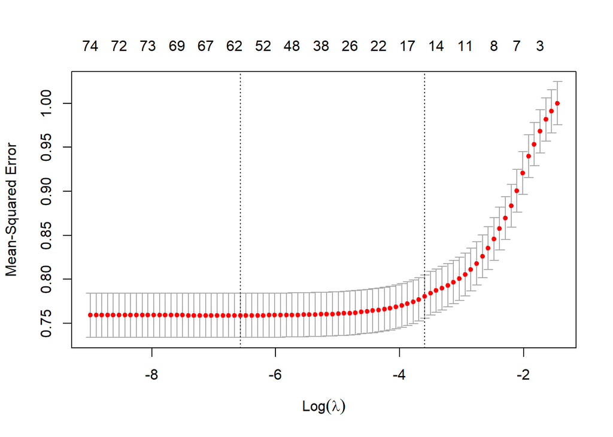

```r
plot(fit.lasso)
```

We can check how many values of $\lambda$ were assessed, and the value deemed to be optimal according to cross-validation. We can also plot the estimated $\hat{\beta}_\lambda$ for all considered $\lambda$.

```r
length(fit.lasso$lambda)
```

```
## [1] 82
```

```r
fit.lasso$lambda.min
```

```
## [1] 0.001399361
```

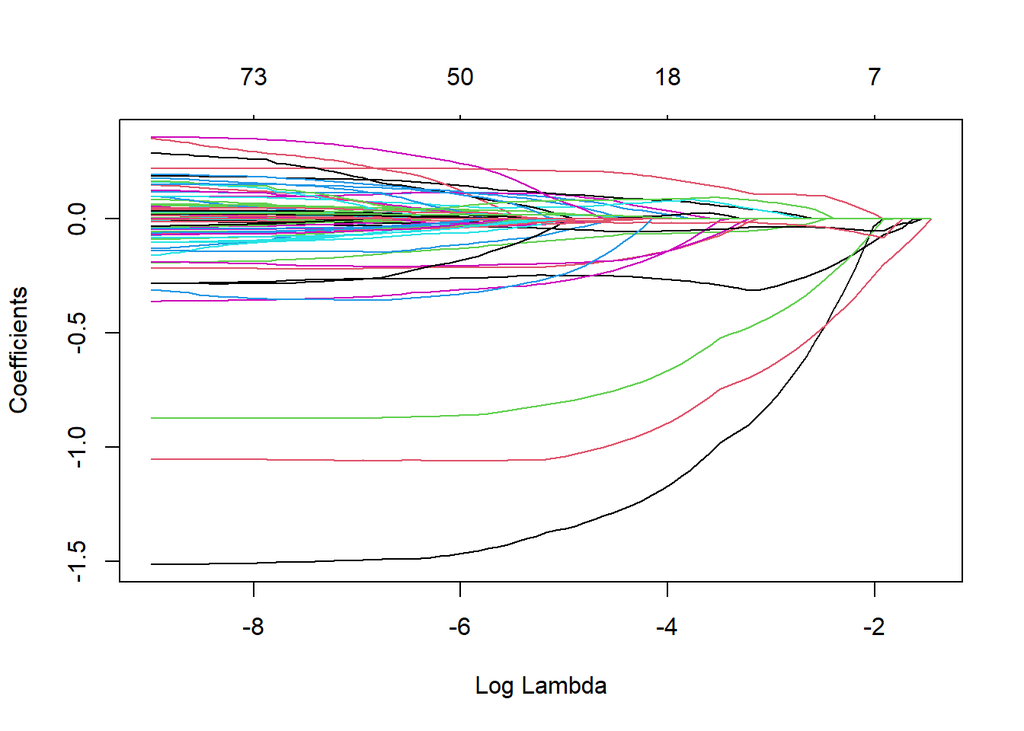

```r
plot(fit.lasso$glmnet.fit, xvar='lambda')
```

We retrieve the estimated coefficients $\hat{\beta}_{\hat{\lambda}}$ with the `coef` function. The argument `s='lambda.min'` indicates to set $\hat{\lambda}$ to the value minimizing $\widehat{MSPE}$. Somewhat strangely, by default `coef` uses $\hat{\lambda}_{1SE}= \hat{\lambda} + \mbox{SE} \hat{\lambda}$.

```r
b.lasso= as.vector(coef(fit.lasso, s='lambda.min'))
round(b.lasso, 3)
```

```
##  [1]  0.633 -0.262  0.220 -0.147  0.000 -0.046 -0.330 -1.491 -1.059 -0.870
## [11]  0.111  0.036  0.112  0.165 -0.216  0.044 -0.141  0.000  0.000 -0.210
## [21] -0.033  0.000  0.000  0.000  0.000 -0.041 -0.021  0.009  0.015 -0.351
## [31] -0.075 -0.007 -0.239  0.204 -0.043 -0.037  0.000  0.000  0.000 -0.011
## [41] -0.011  0.000  0.069  0.055  0.145  0.040  0.045  0.139  0.024 -0.005
## [51]  0.000  0.005  0.048  0.091  0.000  0.001  0.018 -0.047  0.000  0.131
## [61] -0.058 -0.028  0.000  0.000 -0.044 -0.030  0.006  0.288  0.020  0.031
## [71]  0.038 -0.033 -0.061 -0.046  0.009  0.000  0.016
```

How many coefficients are set to a non-zero value in $\hat{\beta}_{\hat{\lambda}}$? What variables are selected? Do they suggest interactions between gender and other variables?

```r
#add your code here
```

### 3.1.2 Via BIC and Extended BIC (EBIC)

We repeat the analyses for LASSO setting $\lambda$ via BIC. We use functions `lasso.bic` from `routines_seminar1.R`

```markdown
lasso.bic <- function(y,x,extended=FALSE) {
  #Select model in LASSO path with best BIC (using LASSO regression estimates)
  #Input
  # - y: vector with response variable
  # - x: design matrix
  #
  #Output: list with the following elements
  # - coef: LASSO-estimated regression coefficient with lambda set via BIC
  # - ypred: predicted y
  # - lambda.opt: optimal value of lambda
  # - lambda: data.frame with bic and number of selected variables for each value of lambda
  require(glmnet)
  fit <- glmnet(x=x,y=y,family='gaussian',alpha=1)
  pred <- cbind(1,x) %*% rbind(fit$a0,fit$beta)
  n <- length(y)
  p <- colSums(fit$beta!=0) + 1
  if (!extended){
    bic <- n * log(colSums((y-pred)^2)/length(y)) + n*(log(2*pi)+1) + log(n)*p
  } else {
    bic <- n * log(colSums((y-pred)^2)/length(y)) + n*(log(2*pi)+1) + log(n)*p + 2*log(choose(ncol(x),p))
  }
  sel <- which.min(bic)
  beta <- c(fit$a0[sel],fit$beta[,sel]); names(beta)[1]= 'Intercept'
  ypred <- pred[,sel]
  ans <- list(coef=beta,ypred=ypred,lambda.opt=fit$lambda[sel],lambda=data.frame(lambda=fit$lambda,bic=bic,nvars=p))
  return(ans)
}
```

To use the BIC criteria, we set `extended=FALSE`.

```r
fit.lassobic= lasso.bic(y=y,x=x[,-1],extended = FALSE)
b.lassobic= fit.lassobic$coef
names(fit.lassobic)
```

```
## [1] "coef"       "ypred"      "lambda.opt" "lambda"
```

To use the EBIC criteria, we set `extended=TRUE`.

```r
fit.lassoebic= lasso.bic(y=y,x=x[,-1],extended = TRUE)
b.lassoebic= fit.lassoebic$coef
names(fit.lassoebic)
```

```
## [1] "coef"       "ypred"      "lambda.opt" "lambda"
```

Is the value of $\lambda$ chosen by BIC larger or smaller than for cross-validation?

```r
#add your code here
```

How many coefficients are set to a non-zero value in $\hat{\beta}_{\hat{\lambda}}$? Are the selected variables different from those selected with $\lambda$ set by cross-validation? Does your interpretation regarding gender imbalances change?

```r
#add your code here
```

## 3.2 Cross-validated $R^2$

### 3.2.1 $\lambda$ set via cross-validation

Unfortunately `cv.glmnet` does not return the out-of-sample predictions $\hat{y}$, just their mean squared prediction error. To obtain cross-validated predictions, and assess their cross-validated $R^2$ with the observed outcome, we use `kfoldCV.lasso` in `routines_seminar1.R`.

```r
cv.lasso= kfoldCV.lasso(y=y,x=x[,-1],K=10,seed=1,criterion="cv")
```

```
## Starting cross-validation..........
```

```r
r2.lassocv= cor(y,cv.lasso$pred)^2
r2.lassocv
```

```
## [1] 0.2410876
```

Does it deviate much from the $R^2$ different to that from OLS? Can you explain why?

```r
#add your answer here
```

### 3.2.2 $\lambda$ set via BIC and EBIC

Again to obtain cross-validated predictions and $R^2$, we use `kfoldCV.lasso` in `routines.R` (in the latter we now set `criterion="bic"` or `criterion="ebic"`)

```r
cv.lassobic= kfoldCV.lasso(y=y,x=x[,-1],K=10,seed=1,criterion="bic")
```

```
## Starting cross-validation..........
```

```r
r2.lassobic= cor(y,cv.lassobic$pred)^2
r2.lassobic
```

```
## [1] 0.2394923
```

How does the predictive ability compare between the different methods to set $\lambda$?

```r
#add your code and analysis here
```

# 4 Ridge

## 4.1 Setting penalization parameter $\lambda$

To set $\lambda$ by cross-validation we use the function `cv.glmnet` again but this time setting parameter `alpha` to 0. Indeed, the objective function optimized in `glmnet` uses an elastic-net penalty which mixes $L_1$ and $L_2$ penalties as follows:

$$\min _{\left(\beta_{0}, \beta\right) \in \mathbb{R}^{p+1}} \frac{1}{2 N} \sum_{i=1}^{N}\left(y_{i}-\beta_{0}-x_{i}^{T} \beta\right)^{2}+\lambda\left[(1-\alpha)\|\beta\|_{2}^{2} / 2+\alpha\|\beta\|_{1}\right]$$
where $\lambda$ is the penalization parameter and $\alpha$ is a mixing parameter. When $\alpha$ is 1 (default), `cv.glmnet` fits a LASSO, when $\alpha$ is 0, `cv.glmnet` fits a Ridge regression.

```r
fit.ridge= cv.glmnet(x=x[,-1], y=y, alpha = 0, nfolds=10)
fit.ridge
```

```
##
## Call:  cv.glmnet(x = x[, -1], y = y, nfolds = 10, alpha = 0)
##
## Measure: Mean-Squared Error
##
##     Lambda Index Measure      SE Nonzero
## min 0.0233   100  0.7608 0.02494      76
## 1se 0.4175    69  0.7846 0.02481      76
```

We plot the estimated mean squared prediction error $\widehat{MSPE}$ as a function of $\lambda$.

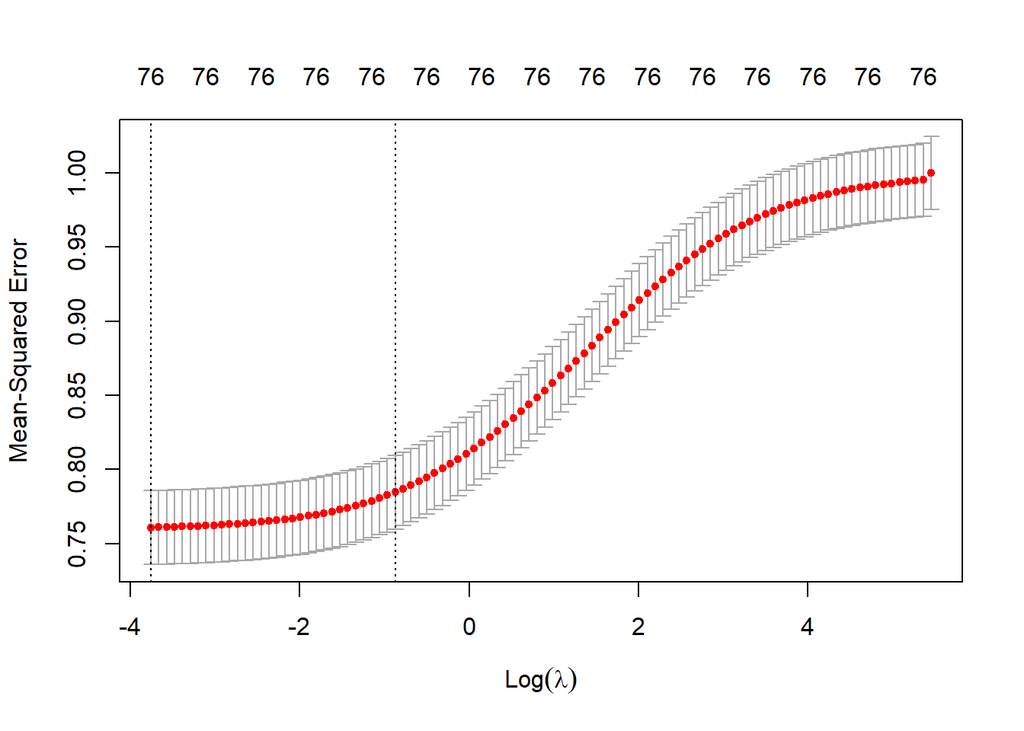

```r
plot(fit.ridge)
```

We plot the cofficient path and see that, this time, all estimated coefficients shrink as $\lambda$ grows but remain non-zero.

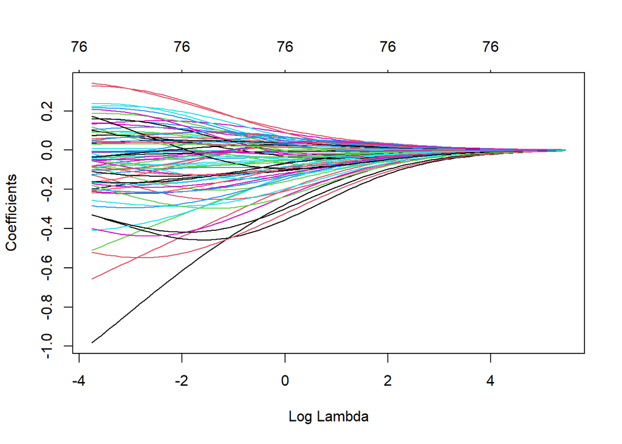

```r
plot(fit.ridge$glmnet.fit, xvar='lambda')
```

```r
b.ridge= as.vector(coef(fit.ridge, s='lambda.min'))
round(b.ridge, 3)
```

```
##  [1]  0.387 -0.198  0.342 -0.088 -0.048 -0.082 -0.082 -0.983 -0.657 -0.511
## [11]  0.161  0.096  0.138  0.102 -0.206  0.072 -0.123  0.008 -0.054 -0.330
## [21] -0.126 -0.087 -0.005 -0.014 -0.010 -0.031 -0.162 -0.090 -0.032 -0.410
## [31] -0.399 -0.329 -0.521  0.118 -0.283 -0.255 -0.170 -0.109 -0.216 -0.200
## [41] -0.163 -0.052  0.133  0.159  0.327  0.187  0.105  0.237  0.207  0.075
## [51]  0.047  0.090  0.214  0.223  0.031  0.036  0.058 -0.038 -0.104 -0.016
## [61] -0.209 -0.160 -0.100 -0.179 -0.198 -0.164 -0.047  0.174 -0.082 -0.053
## [71]  0.052 -0.043 -0.056 -0.037  0.038  0.030  0.042
```

Can we use the BIC and EBIC criteria as presented in the course notes to choose $\lambda$?

```r
#add your code and analysis here
```

We see in that in the plot of $\widehat{MSPE}$ as a function of $\lambda$, the optimal $\lambda$ is the smallest one. Actually, if we extend the window to smaller values, cross-validation keeps selecting the smallest value. The best solution, predicting accuracy wise, is no $L_2$ penalization at all. This illustrates the optimality of MLE for large $n$.

## 4.2 Cross-validated $R^2$

We compute a cross-validated $R^2$ with the function `kfoldCV.ridge` from `routines_seminar1.R`, and adaptation of `kfoldCV.lasso` to Ridge regression.

```r
cv.ridge= kfoldCV.ridge(y=y,x=x[,-1],K=10,seed=1,criterion="cv")
```

```
## Starting cross-validation..........
```

```r
r2.ridgecv= cor(y,cv.ridge$pred)^2
r2.ridgecv
```

```
## [1] 0.2394509
```

# 5 Understanding differences between OLS vs LASSO vs Ridge

It is interesting to compare the point estimates given by OLS vs LASSO and OLS vs Ridge. Just for fun we mark the coefficients with OLS P-value<0.05 in red.

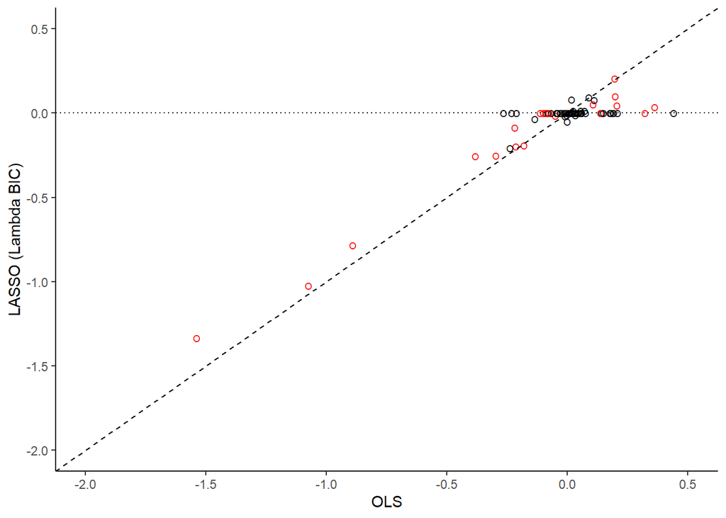

```r
bols= summary(fit.mle)$coef
pvalue= round(bols[,4],4)
col= ifelse(pvalue < 0.05,'red','black')

data.frame(mle= coef(fit.mle)[-1], lassobic= b.lassobic[-1]) %>%
  ggplot(aes(x=mle,y=lassobic)) +
  geom_point(col = col[-1],shape = "O",size=2) +
  geom_abline(slope=1, intercept = 0, linetype = 'dashed') +
  geom_hline(yintercept = 0, linetype = 'dotted') +
  xlab('OLS') +
  ylab('LASSO (Lambda BIC)') +
  coord_cartesian(xlim=c(-2,0.5),ylim=c(-2,0.5)) +
  theme_classic()
```

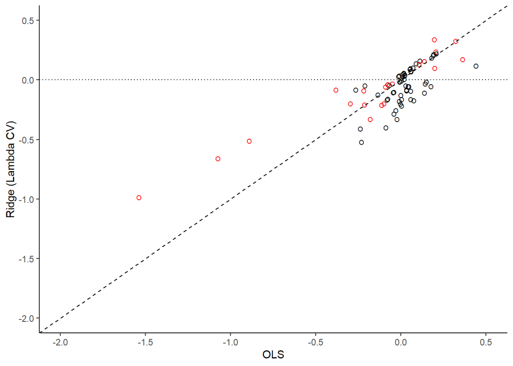

```r
data.frame(mle= coef(fit.mle)[-1], ridgebic= b.ridge[-1]) %>%
  ggplot(aes(x=mle,y=ridgebic)) +
  geom_point(col = col[-1],shape = "O",size=2) +
  geom_abline(slope=1, intercept = 0, linetype = 'dashed') +
  geom_hline(yintercept = 0, linetype = 'dotted') +
  xlab('OLS') +
  ylab('Ridge (Lambda CV)') +
  coord_cartesian(xlim=c(-2,0.5),ylim=c(-2,0.5)) +
  theme_classic()
```

What do you observe?

```r
#add your code and analysis here
```

# 6 Small $n$, large $p$

When $p$ is large in comparison to $n$, MLE estimator variance can be very large due to estimating too many parameters. When $p$ is larger than $n$, OLS fails.

We load the data, log transform the frequency data, rename the columns

```r
data_logx <- log(read_csv(file.path(PATH, "data/Vessel_X.txt"), col_names = FALSE))
data_y <- read_csv(file.path(PATH, "data/Vessel_Y.txt"), col_names = FALSE)
data_y <- data_y[,1]
colnames(data_logx)<-sprintf("%s%i","F",seq(100,400,1))
colnames(data_y)<-sprintf("%s%i","Y",seq(1,ncol(data_y)))
data<-cbind(data_logx,data_y)
```

```r
df <- data.frame(frequency = seq(100,400,1), mean = colMeans(data_logx), variance = diag(cov(data_logx)))
p1 <- ggplot(df)+geom_line(aes(y=mean,x=frequency)) + geom_vline(xintercept = c(102, 120, 144, 194, 228, 253, 319, 355,385),col="grey")
# p2 <- ggplot(df)+geom_line(aes(y=variance,x=frequency))+geom_vline(xintercept = c(102, 120, 144, 194, 228, 253, 319, 355,385),col="grey")
```

A look at the frequency data shows us that predictors are highly correlated.

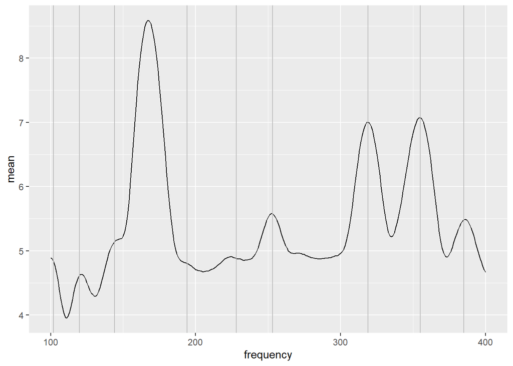

Mean response by frequency

```r
p1
```

```r
# grid.arrange(p1, p2, ncol=2)
```

We can plot how the frequency profile changes for vessels with the largest and lowest content in sodium oxide to try to identify good predictors.

```r
low<-data %>%
  dplyr::arrange(Y1) %>%
  dplyr::slice(1:15) %>%
  dplyr::select(-Y1) %>%
  summarise_all(median)

high<-data %>%
  dplyr::arrange(Y1) %>%
  dplyr::slice((n()-15):n()) %>%
  dplyr::select(-Y1) %>%
  summarise_all(median)

df<-data.frame(frecuencia = seq(100,400,1), bajo = as.numeric(low), alto = as.numeric(high))
```

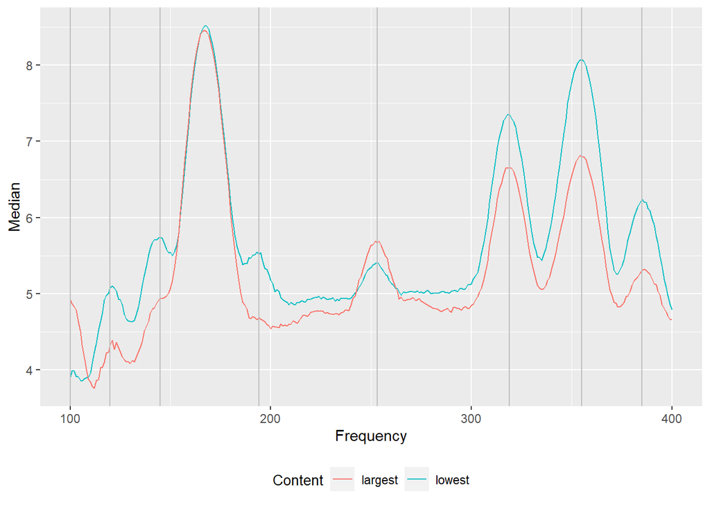

Median response for the 15 vessels with the largest and lowest content in sodium oxide

```r
ggplot(df,aes(x=frecuencia)) +
  geom_line(aes(y=bajo,col="lowest")) +
  geom_line(aes(y=alto,col="largest")) +
  ylab("Median") +
  xlab("Frequency") +
  labs(color="Content") +
  theme(plot.title = element_text(size = 10, face = "bold"),
        legend.position="bottom",
        legend.title = element_text(size = 10)) +
  geom_vline(xintercept = c(100, 120, 145, 194, 253, 319, 355, 385),col="grey")
```

If we try to fit an OLS:

```r
mle_vessel <- lm(Y1~., data = data)
summary(mle_vessel)
```

```
##
## Call:
## lm(formula = Y1 ~ ., data = data)
##
## Residuals:
## ALL 180 residuals are 0: no residual degrees of freedom!
##
## Coefficients: (122 not defined because of singularities)
##              Estimate Std. Error t value Pr(>|t|)
## (Intercept)  -594.355         NA      NA       NA
## F100          143.580         NA      NA       NA
## F101         -326.747         NA      NA       NA
## F102          -58.368         NA      NA       NA
## F103          -46.715         NA      NA       NA
## F104         -232.015         NA      NA       NA
## F105         -151.575         NA      NA       NA
## F106          476.031         NA      NA       NA
## F107          142.645         NA      NA       NA
## F108          188.453         NA      NA       NA
## F109         -351.749         NA      NA       NA
## F110         -164.203         NA      NA       NA
## F111          170.841         NA      NA       NA
## F112          304.547         NA      NA       NA
## F113          199.732         NA      NA       NA
## F114          422.913         NA      NA       NA
## F115           35.936         NA      NA       NA
## F116          215.620         NA      NA       NA
## F117          201.070         NA      NA       NA
## F118           52.131         NA      NA       NA
## F119          -75.449         NA      NA       NA
## F120         -256.848         NA      NA       NA
## F121          492.654         NA      NA       NA
## F122         -235.091         NA      NA       NA
## F123         -333.284         NA      NA       NA
## F124         -357.317         NA      NA       NA
## F125           71.162         NA      NA       NA
## F126          105.373         NA      NA       NA
## F127         -180.932         NA      NA       NA
## F128         -148.523         NA      NA       NA
## F129         -306.601         NA      NA       NA
```

[output cut: 260 more lines]

```
## F390               NA         NA      NA       NA
## F391               NA         NA      NA       NA
## F392               NA         NA      NA       NA
## F393               NA         NA      NA       NA
## F394               NA         NA      NA       NA
## F395               NA         NA      NA       NA
## F396               NA         NA      NA       NA
## F397               NA         NA      NA       NA
## F398               NA         NA      NA       NA
## F399               NA         NA      NA       NA
## F400               NA         NA      NA       NA
##
## Residual standard error: NaN on 0 degrees of freedom
## Multiple R-squared:      1,  Adjusted R-squared:    NaN
## F-statistic:   NaN on 179 and 0 DF,  p-value: NA
```

Let’s say that we managed to reduce our set of potential predictors to 150 variables, and we fit an OLS:

```r
mle_vessel <- lm(Y1~., data = data[,(302-150):302])
summary(mle_vessel)
```

```
##
## Call:
## lm(formula = Y1 ~ ., data = data[, (302 - 150):302])
##
## Residuals:
##      Min       1Q   Median       3Q      Max
## -1.59363 -0.31864  0.03268  0.30465  0.91963
##
## Coefficients:
##              Estimate Std. Error t value Pr(>|t|)
## (Intercept) 119.10319   29.40710   4.050 0.000349 ***
## F251          5.71253    6.24237   0.915 0.367675
## F252          1.98241    6.71902   0.295 0.770062
## F253         -5.09054    6.80810  -0.748 0.460651
## F254          0.36930    5.87097   0.063 0.950276
## F255         -8.79748    6.27328  -1.402 0.171418
## F256          0.06437    5.99019   0.011 0.991500
## F257        -20.89843    6.71141  -3.114 0.004131 **
## F258         11.59557    6.37153   1.820 0.079111 .
## F259          5.47079    6.83781   0.800 0.430170
## F260          8.36111    6.28212   1.331 0.193579
## F261          3.98670    5.19495   0.767 0.449037
## F262         11.68695    5.59798   2.088 0.045719 *
## F263         -1.46155    5.29273  -0.276 0.784397
## F264         16.47483    6.33074   2.602 0.014434 *
## F265          6.33304    5.02770   1.260 0.217846
## F266         -3.65426    7.93597  -0.460 0.648615
## F267         -5.37831    5.12460  -1.050 0.302613
## F268         -6.45169    5.54662  -1.163 0.254240
## F269          7.97778    5.09188   1.567 0.128018
## F270         -8.51503    6.66537  -1.278 0.211558
## F271         -7.18838    5.27055  -1.364 0.183100
## F272         -0.14320    5.75348  -0.025 0.980314
## F273          5.01302    5.01392   1.000 0.325668
## F274         16.79031    5.74181   2.924 0.006638 **
## F275          2.98943    7.72324   0.387 0.701531
## F276         -4.47648    5.02212  -0.891 0.380077
## F277         15.26016    5.33965   2.858 0.007814 **
## F278          7.56300    5.62669   1.344 0.189328
## F279         -3.51265    5.29492  -0.663 0.512313
```

[output cut: 112 more lines]

```
## F392          4.46579    8.93471   0.500 0.620970
## F393          7.27740    6.78110   1.073 0.292036
## F394          0.73196    4.98980   0.147 0.884391
## F395         -3.33098    4.74152  -0.703 0.487961
## F396         -2.24331    6.48619  -0.346 0.731945
## F397          5.31861    5.85131   0.909 0.370863
## F398         -1.89128    5.42724  -0.348 0.729997
## F399         -5.33534    4.65481  -1.146 0.261083
## F400         -9.99400    6.18072  -1.617 0.116714
## ---
## Signif. codes:  0 '***' 0.001 '**' 0.01 '*' 0.05 '.' 0.1 ' ' 1
##
## Residual standard error: 1.149 on 29 degrees of freedom
## Multiple R-squared:  0.9886, Adjusted R-squared:  0.9297
## F-statistic: 16.79 on 150 and 29 DF,  p-value: 4.685e-13
```

The fit has little predictive accuracy. Multicollinearity generates multiple issues numerically and statistically (but no bias).

```r
cv.mle= kfoldCV.mle(y=data$Y1,x=data[,(302-150):301],K=10,seed=1)
r2.mle= cor(cv.mle$pred, data$Y1)^2
r2.mle
```

```
## [1] 0.4007146
```

Now we fit the LASSO. Out of the 301 frequencies, the LASSO selects 31 of them.

```r
fit.lasso= cv.glmnet(x=as.matrix(data_logx), y=data_y$Y1, nfolds=10)
fit.lasso
```

```
##
## Call:  cv.glmnet(x = as.matrix(data_logx), y = data_y$Y1, nfolds = 10)
##
## Measure: Mean-Squared Error
##
##      Lambda Index Measure      SE Nonzero
## min 0.03762   100  0.4396 0.06591      31
## 1se 0.05210    93  0.4988 0.07250      29
```

```r
b.lasso <- as.vector(coef(fit.lasso, s='lambda.min'))
names(b.lasso) <- c('intercept',colnames(data_logx))
b.lasso[b.lasso!=0]
```

```
##   intercept        F100        F101        F102        F103        F104
## 99.12685491  2.09930025  1.72051448  2.54949156  1.26220067  0.84355853
##        F126        F127        F130        F132        F134        F135
## -0.66475481 -0.53127205 -1.05347025 -1.07722679 -0.51758897 -1.68994830
##        F157        F167        F168        F169        F170        F187
##  0.29062520 -6.28363211 -0.30932992 -1.69856597 -1.15842241 -0.30409361
##        F196        F231        F232        F244        F246        F247
## -0.17695249 -1.02498380 -0.06281165  1.08813001  0.31236739  0.47326364
##        F283        F293        F300        F303        F331        F342
## -0.90293306 -1.10759672 -1.30467148 -0.23098635 -0.02018058 -0.79131054
##        F343        F344
## -0.23608622 -0.43830238
```

The predictive accuracy is very high with just 31 predictors.

```r
cv.lassobic= kfoldCV.lasso(x=as.matrix(data_logx), y=data_y$Y1,K=10,seed=1,criterion="cv")
```

```
## Starting cross-validation..........
```

```r
r2.lassobic= cor(data_y$Y1,cv.lassobic$pred)^2
r2.lassobic
```

```
## [1] 0.9773764
```

```r
fit.lasso= cv.glmnet(x=as.matrix(data_logx[,(301-149):30]), y=data_y$Y1, nfolds=10)
cv.lassobic= kfoldCV.lasso(x=as.matrix(data_logx[,(301-149):30]), y=data_y$Y1,K=10,seed=1,criterion="cv")
```

```
## Starting cross-validation..........
```

```r
r2.lassobic= cor(data_y$Y1,cv.lassobic$pred)^2
r2.lassobic
```

```
## [1] 0.81735
```

The Ridge regression outputs nonzero coefficients for all the 301 frequencies…

```r
fit.ridge= cv.glmnet(x=as.matrix(data_logx), y=data_y$Y1, alpha = 0, nfolds=10)
fit.ridge
```

```
##
## Call:  cv.glmnet(x = as.matrix(data_logx), y = data_y$Y1, nfolds = 10,      alpha = 0)
##
## Measure: Mean-Squared Error
##
##     Lambda Index Measure     SE Nonzero
## min  37.62   100   2.775 0.3249     301
## 1se  49.73    94   3.066 0.3751     301
```

```r
b.rigde <- as.vector(coef(fit.ridge, s='lambda.min'))
names(b.rigde) <- c('intercept',colnames(data_logx))
length(b.rigde[b.rigde!=0])
```

```
## [1] 302
```

… and achieves a lowest predictive accuracy.

```r
cv.ridge= kfoldCV.ridge(x=as.matrix(data_logx), y=data_y$Y1,K=10,seed=1,criterion="cv")
```

```
## Starting cross-validation..........
```

```r
r2.ridgecv= cor(data_y$Y1,cv.ridge$pred)^2
r2.ridgecv
```

```
## [1] 0.8670852
```

What happens when predictors are highly correlated is that the Ridge penalty shrinks the coefficients of correlated predictors towards each other while the LASSO tends to pick one of them and discard the others.

```r
b.ridge
```

```
##  [1]  0.387035159 -0.197987897  0.341826882 -0.087915634 -0.047774152
##  [6] -0.082172015 -0.082009838 -0.983075629 -0.656891648 -0.511347654
## [11]  0.160790439  0.096236559  0.138306346  0.101598951 -0.205781900
## [16]  0.072314087 -0.123476139  0.007915571 -0.053639530 -0.329752223
## [21] -0.125782960 -0.086735283 -0.005356358 -0.013644746 -0.010346554
## [26] -0.031033656 -0.161940855 -0.089956202 -0.032006133 -0.409553891
## [31] -0.399256467 -0.328791020 -0.520728561  0.118391414 -0.283283730
## [36] -0.254779247 -0.170152170 -0.108735071 -0.215708489 -0.199939376
## [41] -0.163172667 -0.051520697  0.132592657  0.158774132  0.327158243
## [46]  0.186562637  0.104565975  0.236811288  0.206773429  0.075063879
## [51]  0.047359221  0.089601379  0.214351593  0.222890759  0.030645925
## [56]  0.036040498  0.057974208 -0.037836609 -0.103620307 -0.015582967
## [61] -0.209346373 -0.160181816 -0.100089675 -0.179186876 -0.198310284
## [66] -0.164380243 -0.046913804  0.173688779 -0.082087288 -0.052753778
## [71]  0.051525581 -0.043076293 -0.056204672 -0.037260582  0.038025592
## [76]  0.029782670  0.041564132
```

# 7 Inference for LASSO

We illustrate here the discussion on inference with penalized likelihood methods in the case of LASSO and with simulated data. Function `simdata.cs` generates, for each of `n` independent individuals, `p` covariates that are normally-distributed with mean 0, variance 1, and all pairwise correlations equal to `rho`.

We set `n=100`, `p=200`, `rho=0.5`. The true value of all regression coefficients is 0, except for the last four. You’re encouraged to play around and explore how the results vary as one has different n, p, rho or regression coefficients.

```r
n= 100  # No. observations
p= 200  # No. features
rho= 0.5  # True pairwise correlation across features
beta= c(rep(0, p - 4), -2/3, 1/3, 2/3, 1)

# Simulate data
sim.data= simdata.cs(seed = 2, n, beta, phi = 1, rho)
X= sim.data[['x']]  # covariates
y= sim.data[['y']]  # response
```

## 7.1 LASSO + naive OLS

We first run a two-step analysis strategy that is simple but not quite correct. In Step 1 we use `glmnet` to select variables via LASSO, setting the penalization parameter $\lambda$ via cross-validation.

```r
# Standardise (relevant for glmnet function)
Xstd= scale(X)
ystd= scale(y)
colnames(Xstd)= paste('X', 1:ncol(Xstd), sep = '')

set.seed(123456)
lambda= cv.glmnet(x = Xstd, y = ystd, nfolds = 10)[['lambda.min']]
gfit= glmnet(x = Xstd, y = ystd, standardize = FALSE, lambda = lambda)
b.lasso= coef(gfit)[-1] #estimated coefficients
sel.lasso= (b.lasso != 0)
sum(sel.lasso) #number of selected covariates
```

```
## [1] 24
```

In Step 2 we fit a linear model using the variables selected in Step 1 via ordinary least-squares (R function `lm`). We display the first few estimated coefficients, confidence intervals and P-values.

```r
lm.afterlasso= lm(y ~ -1 + X[, sel.lasso])
ci.lasso= matrix(0, nrow = p, ncol = 4)
colnames(ci.lasso) = c('estimate','ci_low','ci_upp', 'p_value')
rownames(ci.lasso) = paste("X",1:ncol(X),sep="")
ci.lasso[sel.lasso, 1:3] = cbind(coef(lm.afterlasso), confint(lm.afterlasso))
ci.lasso[sel.lasso, 4]= summary(lm.afterlasso)$coef[,4]
ci.lasso[!sel.lasso,4]= NA
```

We round estimates to 3 decimals and P-values to 4 decimals, and display the output for the variables for which the LASSO estimate was non-zero.

```r
ci.lasso[,1:3]= round(ci.lasso[,1:3], 3)
ci.lasso[,4]= round(ci.lasso[,4], 4)
ci.lasso[sel.lasso, ]
```

```
##      estimate ci_low ci_upp p_value
## X2      0.225  0.017  0.433  0.0346
## X9      0.298  0.075  0.521  0.0096
## X26    -0.208 -0.395 -0.021  0.0298
## X32    -0.241 -0.448 -0.033  0.0235
## X65     0.323  0.118  0.529  0.0025
## X70     0.125 -0.104  0.355  0.2803
## X86     0.168 -0.076  0.411  0.1738
## X89    -0.166 -0.359  0.026  0.0890
## X91    -0.358 -0.593 -0.122  0.0034
## X102   -0.279 -0.523 -0.034  0.0261
## X112    0.191 -0.056  0.438  0.1282
## X120    0.195 -0.056  0.446  0.1258
## X122    0.015 -0.204  0.233  0.8944
## X143    0.156 -0.080  0.391  0.1918
## X146    0.099 -0.102  0.300  0.3313
## X148    0.250  0.039  0.460  0.0207
## X153    0.151 -0.078  0.379  0.1933
## X178    0.171 -0.026  0.367  0.0876
## X183   -0.280 -0.483 -0.076  0.0077
## X189   -0.487 -0.730 -0.245  0.0001
## X197   -0.609 -0.860 -0.358  0.0000
## X198    0.264  0.051  0.477  0.0158
## X199    0.861  0.612  1.109  0.0000
## X200    0.753  0.537  0.969  0.0000
```

We compare the selected variables with the simulation truth. The cross-tabulation table below counts the number of true positives, false positives and false negatives.

```r
sel.lasso= rep(FALSE, nrow(ci.lasso))
sel.lasso[ci.lasso[,4] < 0.05]= TRUE
table(sel.lasso, beta != 0)
```

```
##
## sel.lasso FALSE TRUE
##     FALSE   186    0
##     TRUE     10    4
```

Finally we plot the confidence intervals, along with the true parameter values. Intervals that do not contain the true value are plotted in red.

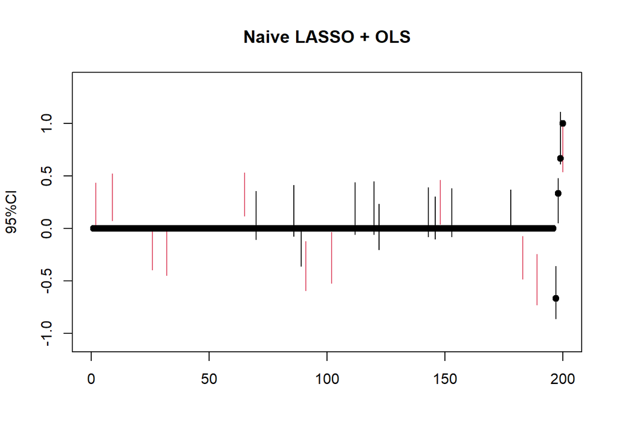

```r
cols= ifelse(beta < ci.lasso[, 2] | beta > ci.lasso[, 3], 2, 1)
plot(1:p, beta, ylim=1.25*range(ci.lasso[,1:3]), xlim=c(0,nrow(ci.lasso)), ylab='95%CI', xlab='', main='Naive LASSO + OLS')
segments(y0 = ci.lasso[, 2], y1 = ci.lasso[, 3], x0 = 1:nrow(ci.lasso), col = cols)
points(1:p, beta, pch = 16)
```

## 7.2 LASSO + post-selection inference (Lee et al, 2016, AOS)

We now run LASSO followed by post-selection inference. The main advantage of this strategy is that there are some theoretical guarantees that the obtained CI’s have the correct coverage (i.e. we expect them to contain the true regression coefficients 95% of the time).

We use function `lassopost`. This is a wrapper function created to make your life easier, it calls several functions from package `selectiveInference` and returns the CI’s.

We display the point estimates and post-selection adjusted 95% CI’s and P-values (rounded to 4 decimal places). Notice that the set of variables with non-zero LASSO point-estimate differs from our earlier LASSO run. The reason is that the regularization parameter $\lambda$ is set via 10-fold cross-validation, hence running cross-validation multiple times returns different $\lambda$’s and in turn different $\hat{\beta}$’s.

```r
ci.lassopost= lassopost(y, X, method.lambda='cv')
round(ci.lassopost[ci.lassopost[,1] != 0,], 4)
```

```
##      estimate  ci.low   ci.up pvalue
## X2     0.1223 -0.3123  0.4595 0.3291
## X9     0.1437 -0.3161  0.9089 0.2350
## X26   -0.0977 -0.7449  0.3600 0.3028
## X32   -0.1277 -0.5562  0.7238 0.5275
## X65    0.2149 -1.7415  0.5181 0.6579
## X70    0.0514 -1.2034  0.2276 0.7573
## X83    0.0726 -2.9758  1.6006 0.6240
## X86    0.1458 -0.4318  3.5651 0.1443
## X89   -0.0810 -1.2968  0.5893 0.3117
## X91   -0.1960 -0.7110  1.6759 0.6186
## X102  -0.0829 -0.3412  1.5624 0.7407
## X112   0.1324 -0.4350  3.9524 0.1392
## X120   0.0943 -1.8893  0.2212 0.7995
## X122   0.0750 -1.5041  0.5532 0.6762
## X140  -0.0929 -0.5173  1.5187 0.6825
## X143   0.1140 -0.2018  2.2608 0.1198
## X145  -0.0592 -3.1822  2.8000 0.4656
## X146   0.0637 -1.0208  0.2202 0.7270
## X148   0.1613 -0.2257  0.5687 0.2246
## X153   0.1151 -0.9924  0.3671 0.6274
## X163  -0.1117 -0.6149  4.4873 0.8149
## X165   0.0775    -Inf -0.0154 0.9521
## X178   0.1355 -1.0438  0.7179 0.5329
## X183  -0.1793 -0.7038  0.2969 0.2412
## X189  -0.2654 -0.5710  3.2481 0.7470
## X194  -0.1449 -0.8934  1.5226 0.5766
## X197  -0.4148 -0.7997  1.4767 0.4902
## X198   0.1351 -0.3851  0.8190 0.2853
## X199   0.4670  0.1523  2.4101 0.0218
## X200   0.3937 -0.4058  3.3455 0.1054
```

A better alternative is to set $\lambda$ via the BIC, which typically does a better job at identifying the set of variables that truly have an effect.

```r
ci.lassopost= lassopost(y, X, method.lambda='bic')
round(ci.lassopost[ci.lassopost[,1] != 0,], 4)
```

```
##      estimate  ci.low  ci.up pvalue
## X86    0.1711 -0.1243 0.2959 0.1653
## X199   0.3252  0.2002 0.4480 0.0001
## X200   0.4157  0.2856 0.5800 0.0000
```

We tabulate number of true positives, false positives and false negatives.

```r
sel.lassopost= rep(FALSE, nrow(ci.lassopost))
sel.lassopost[ci.lassopost[,4] < 0.05]= TRUE
table(sel.lassopost, beta != 0)
```

```
##
## sel.lassopost FALSE TRUE
##         FALSE   196    2
##         TRUE      0    2
```

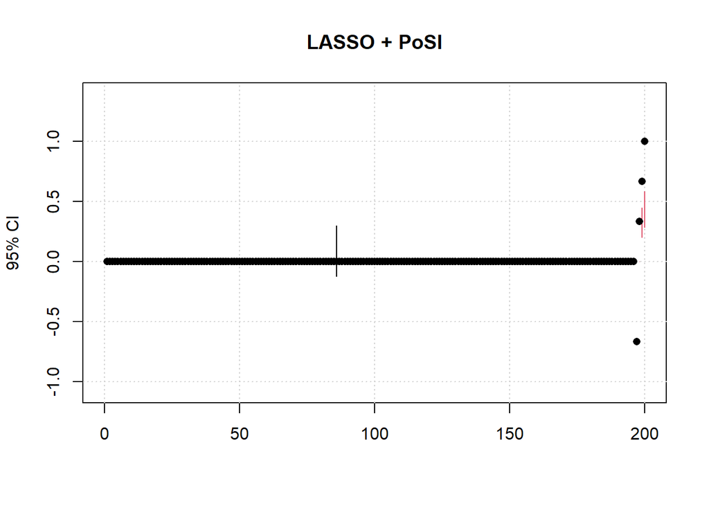

```r
plot(NA, ylim=1.25*range(ci.lasso[,1:3]), xlim=c(0,nrow(ci.lassopost)), ylab='95% CI', xlab='', main='LASSO + PoSI')
grid()
cols= ifelse(beta < ci.lassopost[, 2] | beta > ci.lassopost[, 3], 2, 1)
segments(y0 = ci.lassopost[, 2], y1 = ci.lassopost[, 3], x0 = 1:nrow(ci.lassopost), col = cols)
points(1:p, beta, pch = 16)
```

## 7.3 Bootstrap LASSO

We now obtain confidence intervals for LASSO parameters by bootstrap with the funcion `bootLasso` from the package `HDCI`. The parameter `B` controls the number of iterations of bootstrap, `type.boot` controls the choice of method between residual bootstap and paired bootstrap and `alpha` the desired coverage.

```r
bootlasso <- bootLasso(X, y, B = 500, type.boot = "paired", alpha = 0.05)
```

```r
ci.bootlasso <- t(bootlasso$interval)
df <- data.frame(sprintf("X%s",seq(1:ncol(X))),bootlasso$Beta,ci.bootlasso)
colnames(df) <- c('variable','estimate','ci.low','ci.up')
df[df$estimate != 0,]
```

```
##     variable     estimate      ci.low      ci.up
## 2         X2  0.003158935  0.00000000  0.2345120
## 9         X9  0.059580033  0.00000000  0.2749529
## 65       X65  0.056724457  0.00000000  0.2155524
## 86       X86  0.083980273  0.00000000  0.2514368
## 112     X112  0.022354558  0.00000000  0.2717024
## 120     X120  0.039677443  0.00000000  0.3171326
## 122     X122  0.008053510  0.00000000  0.2226649
## 143     X143  0.069249724  0.00000000  0.3112184
## 146     X146  0.038065683  0.00000000  0.3086610
## 148     X148  0.120818857  0.00000000  0.2993042
## 153     X153  0.095537802  0.00000000  0.2442280
## 183     X183 -0.020831379 -0.22427080  0.0000000
## 197     X197 -0.461012102 -0.65062591 -0.1061905
## 198     X198  0.119339129  0.00000000  0.3233191
## 199     X199  0.545218143  0.09583865  0.8099547
## 200     X200  0.629117125  0.17717954  0.8541177
```

We tabulate the number of true positives, false positives and false negatives.

```r
sel.bootlasso= rep(TRUE, nrow(df))
sel.bootlasso[(0 >= df$ci.low) & (0 <= df$ci.up)] <- FALSE
table(sel.bootlasso, beta != 0)
```

```
##
## sel.bootlasso FALSE TRUE
##         FALSE   196    1
##         TRUE      0    3
```

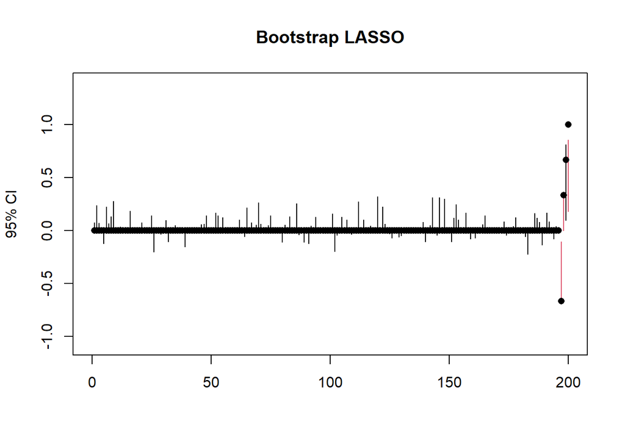

```r
plot(NA, ylim=1.25*range(ci.lasso[,1:3]), xlim=c(0,nrow(ci.bootlasso)), ylab='95% CI', xlab='', main='Bootstrap LASSO')
cols= ifelse(beta < ci.bootlasso[, 1] | beta > ci.bootlasso[, 2], 2, 1)
segments(y0 = ci.bootlasso[, 1], y1 = ci.bootlasso[, 2], x0 = 1:nrow(ci.bootlasso), col = cols)
points(1:p, beta, pch = 16)
```

# 8 Homework (to be turned in)

In this lab we have implemented LASSO for Gaussian linear regression but LASSO can also be used for GLMs. In this homework, you will implement LASSO for logistic regression (GLM for Bernoulli response) on the spam dataset with `glmnet`. Check `help("glmnet")` and the package vignette for further information.

The spam dataset consists of information from 4601 email messages, in a study to try to predict whether the email was junk email, or “spam.” The objective was to design an automatic spam detector that could filter out spam before clogging the users’ mailboxes. For all 4601 email messages, the true outcome (email type) email or spam is available, along with the relative frequencies of 57 of the most commonly occurring words and punctuation marks in the email message.

The file `spam.info.txt` contains information about the dataset, `spambase.names` the names of the variables and `spam.data` the actual data. The last column of `spam.data` denotes whether the e-mail was considered spam (1) or not (0). The data can be loaded with the following code:

```r
spam <- read.table(file.path(PATH, 'data/spam.data'), quote="\"", comment.char="")
spam.names <- c(read.table("data/spambase.names", sep = ":", skip = 33, nrows = 53, as.is = TRUE)[,
1], "char_freq_#", read.table("data/spambase.names", sep = ":", skip = 87, nrows = 3,
as.is = TRUE)[, 1], "spam.01")
names(spam) <- spam.names
spam <- spam[sample(nrow(spam)),]
```

Compare MLE, LASSO-CV and LASSO-BIC estimates in a 1 page report indicating the number of selected variables and 10-fold cross-validated $R^2$ for each of these 3 methods. Include the R code you used and a discussion on the following question: if you were asked to choose one of these methods to obtain results for your applied research paper, which one would you pick, and why?